# Problem Set 2

Author

Tesahe Tunson

Published

October 16, 2026

https://github.com/tesahe/ec422_ps2_tunson

## Data

The dataset is monthly, seasonally adjusted unemployment rates for the United States as a whole and California, New York, Oregon, and Texas. The data comes from FRED database retrieved through tidyquant, from the years 1976 to 2026.

```r
library(tidyquant)
library(tidyverse)
library(knitr)

unemp_raw <- read_rds("data/unemp_raw.rds")

head(unemp_raw)
```

```
# A tibble: 6 × 3
  symbol date       price
  <chr>  <date>     <dbl>
1 UNRATE 1976-01-01   7.9
2 UNRATE 1976-02-01   7.7
3 UNRATE 1976-03-01   7.6
4 UNRATE 1976-04-01   7.7
5 UNRATE 1976-05-01   7.4
6 UNRATE 1976-06-01   7.6
```

## Wrangling

I renamed price to unemployment_rate, added readable region labels, filled the missing October 2025 value (government shutdown) with September 2025’s value, and computed the month-over-month change in percentage points.

```r
unemp <- unemp_raw |>
  rename(unemployment_rate = price) |>
  mutate(region = case_when(
    symbol == "UNRATE" ~ "United States",
    symbol == "ORUR"   ~ "Oregon",
    symbol == "CAUR"   ~ "California",
    symbol == "TXUR"   ~ "Texas",
    symbol == "NYUR"   ~ "New York"
  ))

unemp <- unemp |>
  arrange(region, date) |>
  group_by(region) |>
  mutate(
    unemployment_rate = replace(
      unemployment_rate,
      date == as.Date("2025-10-01"),
      unemployment_rate[date == as.Date("2025-09-01")]
    )
  ) |>
  ungroup()

unemp <- unemp |>
  arrange(region, date) |>
  group_by(region) |>
  mutate(unemployment_rate_change = unemployment_rate - lag(unemployment_rate)) |>
  ungroup()

unemp_recent <- unemp |>
  filter(date >= as.Date("2015-01-01"))
```

### Summary statistics, full sample (1976–present)

```r
unemp_summary <- unemp |>
  group_by(region) |>
  summarize(
    mean_rate = mean(unemployment_rate, na.rm = TRUE),
    min_rate  = min(unemployment_rate,  na.rm = TRUE),
    max_rate  = max(unemployment_rate,  na.rm = TRUE)
  )

kable(unemp_summary, digits = 2,
      col.names = c("Region", "Mean (%)", "Min (%)", "Max (%)"),
      caption = "Unemployment rate summary statistics, 1976–present")
```

Unemployment rate summary statistics, 1976–present

| Region | Mean (%) | Min (%) | Max (%) |
| --- | --- | --- | --- |
| California | 7.07 | 3.8 | 16.1 |
| New York | 6.35 | 3.8 | 16.7 |
| Oregon | 6.66 | 3.4 | 13.7 |
| Texas | 5.85 | 3.4 | 12.8 |
| United States | 6.05 | 3.4 | 14.8 |

### Summary statistics, 2015–present

This table shows unemployment statistics only from 2015 to present, restricting the sample size to only 11 years. Average unemployment is lower across the board compared to the full sample. This is probably due to some high unemployment times being excluded, specifically recessions in the 1980s, 1990s, and late 2000s.

```r
unemp_recent_summary <- unemp_recent |>
  group_by(region) |>
  summarize(
    mean_rate = mean(unemployment_rate, na.rm = TRUE),
    min_rate  = min(unemployment_rate,  na.rm = TRUE),
    max_rate  = max(unemployment_rate,  na.rm = TRUE)
  )

kable(unemp_recent_summary, digits = 2,
      col.names = c("Region", "Mean (%)", "Min (%)", "Max (%)"),
      caption = "Unemployment rate summary statistics, 2015–present")
```

Unemployment rate summary statistics, 2015–present

| Region | Mean (%) | Min (%) | Max (%) |
| --- | --- | --- | --- |
| California | 5.63 | 3.8 | 16.1 |
| New York | 5.10 | 3.8 | 16.7 |
| Oregon | 4.75 | 3.4 | 13.7 |
| Texas | 4.58 | 3.4 | 12.8 |
| United States | 4.62 | 3.4 | 14.8 |

### Largest monthly increases and decreases, excluding 2020

The COVID-19 monthly increase is excluded from this table as its far larger from any other period due to the external influence of the worldwide shutdown. Changes are measured in percentage points.

The largest increases are always around a recession, specifically in 2008, 2009, and 1980. The single largest increase is in Texas in 2009 (+1.1 points).

```r
unemp_no_covid <- unemp |>
  filter(year(date) != 2020)

unemp_top_increases_no_covid <- unemp_no_covid |>
  slice_max(order_by = unemployment_rate_change, n = 5)

unemp_top_decreases_no_covid <- unemp_no_covid |>
  slice_min(order_by = unemployment_rate_change, n = 5)

kable(unemp_top_increases_no_covid |>
        select(region, date, unemployment_rate, unemployment_rate_change),
      digits = 2,
      col.names = c("Region", "Month", "Rate (%)", "Change (pp)"),
      caption = "Five largest month-over-month increases, excluding 2020")
```

Five largest month-over-month increases, excluding 2020

| Region | Month | Rate (%) | Change (pp) |
| --- | --- | --- | --- |
| Texas | 2009-05-01 | 7.6 | 1.1 |
| Oregon | 2008-12-01 | 8.9 | 0.7 |
| Oregon | 2008-11-01 | 8.2 | 0.7 |
| Oregon | 2009-01-01 | 9.6 | 0.7 |
| Oregon | 1980-03-01 | 7.4 | 0.6 |
| United States | 1980-04-01 | 6.9 | 0.6 |

```r
kable(unemp_top_decreases_no_covid |>
        select(region, date, unemployment_rate, unemployment_rate_change),
      digits = 2,
      col.names = c("Region", "Month", "Rate (%)", "Change (pp)"),
      caption = "Five largest month-over-month decreases, excluding 2020")
```

Five largest month-over-month decreases, excluding 2020

| Region | Month | Rate (%) | Change (pp) |
| --- | --- | --- | --- |
| United States | 1983-07-01 | 9.4 | -0.7 |
| New York | 2021-09-01 | 6.2 | -0.6 |
| Oregon | 1977-05-01 | 7.8 | -0.5 |
| California | 2021-07-01 | 7.4 | -0.5 |
| California | 2021-09-01 | 6.5 | -0.5 |
| New York | 2021-07-01 | 7.0 | -0.5 |
| United States | 2010-12-01 | 9.3 | -0.5 |
| United States | 2014-04-01 | 6.2 | -0.5 |
| United States | 2021-07-01 | 5.4 | -0.5 |

## Visualization

### Unemployment rates over time

This plot shows the monthly unemployment rate for all regions from 1976 to 2026. They are usually correlated, rising and falling together during recessions and recoveries. The COVID-19 spike is by far the largest increase in the sample. However, Texas had it’s own spike in the mid 1980s possibly due to oil prices.

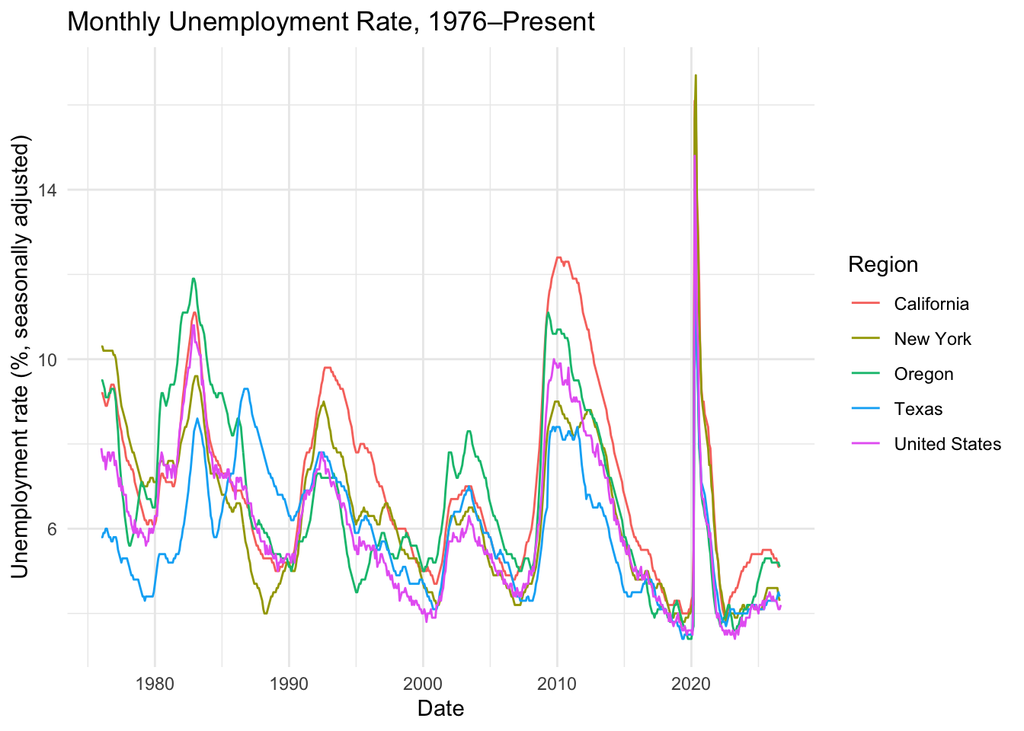

```r
ggplot(unemp, aes(x = date, y = unemployment_rate, color = region)) +
  geom_line() +
  labs(
    title = "Monthly Unemployment Rate, 1976–Present",
    x = "Date",
    y = "Unemployment rate (%, seasonally adjusted)",
    color = "Region"
  ) +
  theme_minimal()
```

### Unemployment rates by region

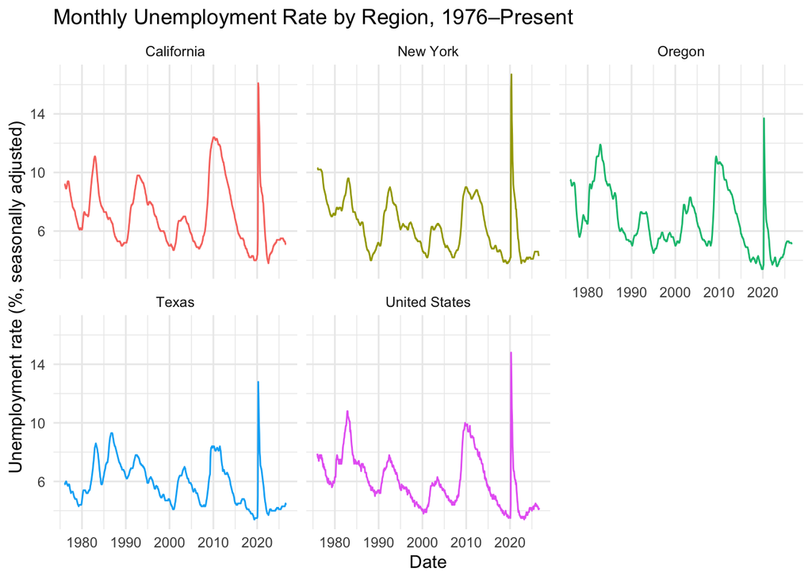

```r
ggplot(unemp, aes(x = date, y = unemployment_rate, color = region)) +
  geom_line() +
  facet_wrap(~ region) +
  labs(
    title = "Monthly Unemployment Rate by Region, 1976–Present",
    x = "Date",
    y = "Unemployment rate (%, seasonally adjusted)"
  ) +
  theme_minimal() +
  theme(legend.position = "none")
```

### Average unemployment rate by region

This chart shows each region’s average unemployment rate in total from 1976 to 2026. Texas has the lowest average and California has the highest.

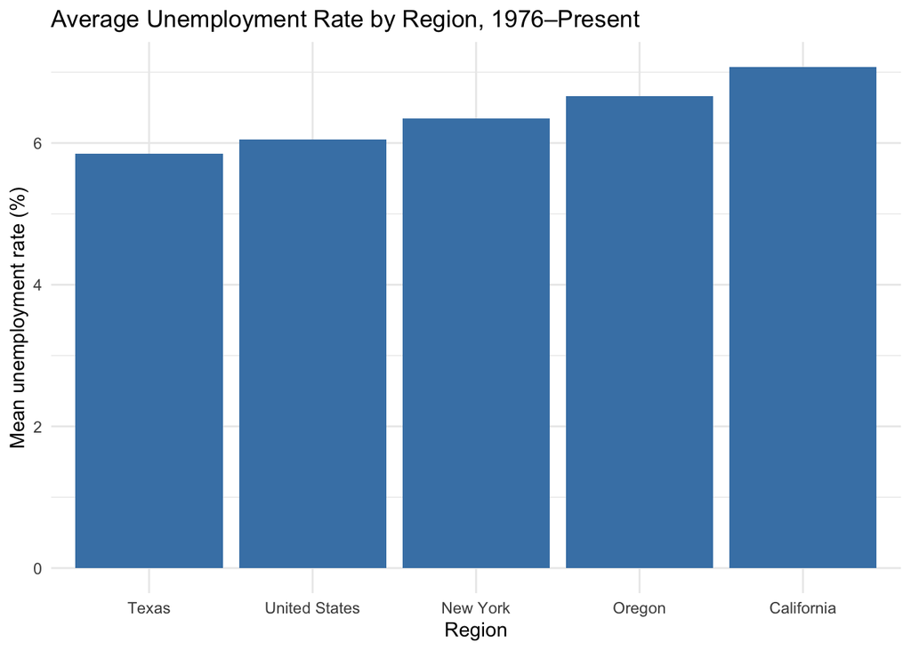

```r
ggplot(unemp_summary, aes(x = fct_reorder(region, mean_rate), y = mean_rate)) +
  geom_col(fill = "steelblue") +
  labs(
    title = "Average Unemployment Rate by Region, 1976–Present",
    x = "Region",
    y = "Mean unemployment rate (%)"
  ) +
  theme_minimal()
```

### My choice: the COVID-19 shock

I chose a specific sample from the years 2019 to 2022 to analyze the largest spike during COVID-19. Unemployment jumped with New York (16.7%) and California (16.1%) being the highest. Texas and Oregon had smaller spikes and recovered faster, while California and New York took longer. I think this is either because of having more urban areas representing a lot of the labor force that were hit harder by the economy, or it’s because those areas have people living in closer proximity and had to react stronger to the virus.

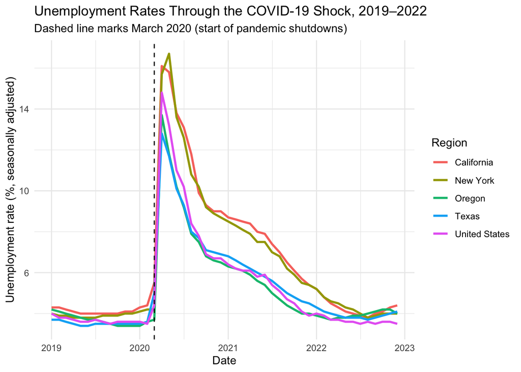

```r
unemp |>
  filter(date >= as.Date("2019-01-01"), date <= as.Date("2022-12-01")) |>
  ggplot(aes(x = date, y = unemployment_rate, color = region)) +
  geom_line(linewidth = 1) +
  geom_vline(xintercept = as.Date("2020-03-01"), linetype = "dashed") +
  labs(
    title = "Unemployment Rates Through the COVID-19 Shock, 2019–2022",
    subtitle = "Dashed line marks March 2020 (start of pandemic shutdowns)",
    x = "Date",
    y = "Unemployment rate (%, seasonally adjusted)",
    color = "Region"
  ) +
  theme_minimal()
```

## Reflection

The use of libraries was pretty straightforward, especially with the use of AI to explain new functions instead of looking through that library’s website. I only got tripped up when using R to render the graphs and using the right formatting to get it on Quarto rather than the functionality of the code. That is also what I feel much more comfortable with after this assignment, formatting my code correctly with a final document in mind. I am comfortable with coding but don’t use RStudio that much compared to other IDEs, but I feel more comfortable with the general interface and using the terminal inside RStudio now as well.